## **Исследование сетевых параметров публичных DNS серверов.**

### **Цель работы**

Проанализировать сетевые параметры публичных DNS серверов, сделать мотивированный вывод о предпочтительных серверах

### **Используемое ПО**

Rstudio IDE  
tracert  
ping  
whois  
2ip

### **Исследуемые провайдеры DNS**

1. Google Public DNS
2. Cloudflare DNS
3. OpenDNS
4. Ростелеком МРФ “ЮГ”

### **Варианты решения задачи**

Выполним задание с помощью утилиты tracert

### **Ход работы**

По исследуемым серверам собрать следующие данные:  
- маршрут  
- местоположение каждого узла маршрута к DNS-серверу  
- организацию, владеющую каждым узлом маршрута к DNS-серверу  
- среднюю RTT к DNS-серверу  
- выделить те узлы маршрута, которые вносят наибольшую временную задержку при передаче

1. **Google Public DNS - 8.8.8.8**
- маршрут

```
> tracert 8.8.8.8

Трассировка маршрута к dns.google [8.8.8.8]
с максимальным числом прыжков 30:

  1     2 ms     1 ms     1 ms  TP-LINK.Home [192.168.1.1]
  2    24 ms    27 ms    24 ms  krdr-bras4.ug.ip.rostelecom.ru [178.34.128.7]
  3    23 ms    31 ms    24 ms  178.34.130.6
  4    73 ms    64 ms    58 ms  87.226.181.89
  5    56 ms    57 ms    58 ms  74.125.52.232
  6    59 ms    58 ms    57 ms  108.170.250.66
  7    73 ms    73 ms    73 ms  216.239.50.132
  8    74 ms    72 ms    72 ms  209.85.254.6
  9    74 ms    73 ms    75 ms  216.239.47.203
 10     *        *        *     Превышен интервал ожидания для запроса.
 11     *        *        *     Превышен интервал ожидания для запроса.
 12     *        *        *     Превышен интервал ожидания для запроса.
 13     *        *        *     Превышен интервал ожидания для запроса.
 14     *        *        *     Превышен интервал ожидания для запроса.
 15     *        *        *     Превышен интервал ожидания для запроса.
 16     *        *        *     Превышен интервал ожидания для запроса.
 17     *        *        *     Превышен интервал ожидания для запроса.
 18     *        *        *     Превышен интервал ожидания для запроса.
 19   127 ms   132 ms     *     dns.google [8.8.8.8]
 20   141 ms   201 ms   118 ms  dns.google [8.8.8.8]

Трассировка завершена.
```

- местоположение узлов

| Узел | Местоположенеи |
| --- | --- |
| 192.168.1.1 | Краснодар |
| 178.34.128.7 | Ставрополь |
| 178.34.130.6 | Ставрополь |
| 87.226.181.89 | Москва |
| 74.125.52.232 | Даллес(США) |
| 108.170.250.66 | Маунтин-Вью(США) |
| 216.239.50.132 | Великобритания |
| 209.85.254.6 | США |
| 216.239.47.203 | Эмеривилл, Калифорния |
| 8.8.8.8 | Нью-Йорк |

- организации

| Узел | Организация |
| --- | --- |
| 192.168.1.1 | ROSTELECOM |
| 178.34.128.7 | ROSTELECOM |
| 178.34.130.6 | ROSTELECOM |
| 87.226.181.89 | Rostelecom |
| 74.125.52.232 | Google LLC |
| 108.170.250.66 | Google LLC |
| 216.239.50.132 | Google LLC |
| 209.85.254.6 | Google LLC |
| 216.239.47.203 | Google LLC |
| 8.8.8.8 | Google LLC |

- среднее RTT к DNS-серверу

[output not shown]

```
> tracert 1.1.1.1

Трассировка маршрута к one.one.one.one [1.1.1.1]
с максимальным числом прыжков 30:

  1     3 ms     1 ms     2 ms  TP-LINK.Home [192.168.1.1]
  2    24 ms    23 ms    25 ms  krdr-bras4.ug.ip.rostelecom.ru [178.34.128.7]
  3    24 ms    24 ms    24 ms  178.34.130.6
  4    24 ms    26 ms    24 ms  178.34.130.154
  5    74 ms    76 ms    75 ms  rostel-gw.ip4.gtt.net [77.67.90.97]
  6    67 ms    66 ms    65 ms  ae1-500.cr1-stk3.ip4.gtt.net [77.67.90.96]
  7    76 ms    76 ms    76 ms  cloudflare-gw.cr0-stk3.ip4.gtt.net [141.136.101.178]
  8    75 ms    75 ms    74 ms  one.one.one.one [1.1.1.1]

Трассировка завершена.
```

- местоположение узлов

| Узел | Местоположенеи |
| --- | --- |
| 192.168.1.1 | Краснодар |
| 178.34.128.7 | Ставрополь |
| 178.34.130.6 | Ставрополь |
| 178.34.130.154 | Ставрополь |
| 77.67.90.97 | Ирландия |
| 77.67.90.96 | Ирландия |
| 141.136.101.178 | Париж |
| 1.1.1.1 | Австралия |

- организации

| Узел | Организация |
| --- | --- |
| 192.168.1.1 | ROSTELECOM |
| 178.34.128.7 | ROSTELECOM |
| 178.34.130.6 | ROSTELECOM |
| 178.34.130.154 | ROSTELECOM |
| 77.67.90.97 | Tinet International Network |
| 77.67.90.96 | Tinet International Network |
| 141.136.101.178 | Tinet International Network |
| 1.1.1.1 | APNIC and Cloudflare DNS |

- среднее RTT к DNS-серверу

```
>ping 1.1.1.1

Обмен пакетами с 1.1.1.1 по с 32 байтами данных:
Ответ от 1.1.1.1: число байт=32 время=74мс TTL=59
Ответ от 1.1.1.1: число байт=32 время=65мс TTL=59
Ответ от 1.1.1.1: число байт=32 время=64мс TTL=59
Ответ от 1.1.1.1: число байт=32 время=121мс TTL=59

Статистика Ping для 1.1.1.1:
    Пакетов: отправлено = 4, получено = 4, потеряно = 0
    (0% потерь)
Приблизительное время приема-передачи в мс:
    Минимальное = 64мсек, Максимальное = 121 мсек, Среднее = 81 мсек
```

- наибольшую временную задержку при передаче вносит 2-й, 5-й узел.
3. **OpenDNS - 208.67.222.222**
- маршрут

```
>tracert 208.67.222.222

Трассировка маршрута к resolver1.opendns.com [208.67.222.222]
с максимальным числом прыжков 30:

  1     3 ms    12 ms     1 ms  TP-LINK.Home [192.168.1.1]
  2    25 ms    24 ms    24 ms  krdr-bras4.ug.ip.rostelecom.ru [178.34.128.7]
  3    25 ms    31 ms    33 ms  178.34.130.6
  4    67 ms    67 ms    72 ms  87.226.133.59
  5    71 ms    67 ms   123 ms  ae1-500.cr1-stk3.ip4.gtt.net [77.67.90.96]
  6    90 ms    89 ms    89 ms  ae13.cr5-ams1.ip4.gtt.net [213.200.117.202]
  7    94 ms    94 ms    94 ms  opendns-gw.ip4.gtt.net [77.67.66.70]
  8    94 ms    95 ms    93 ms  resolver1.opendns.com [208.67.222.222]

Трассировка завершена.
```

- местоположение узлов

| Узел | Местоположенеи |
| --- | --- |
| 192.168.1.1 | Краснодар |
| 178.34.128.7 | Ставрополь |
| 178.34.130.6 | Ставрополь |
| 87.226.133.59 | Москва |
| 77.67.90.96 | Ирландия |
| 213.200.117.202 | США |
| 77.67.66.70 | Ирландия |
| 208.67.222.222 | San Francisco |

- организации

| Узел | Организация |
| --- | --- |
| 192.168.1.1 | ROSTELECOM |
| 178.34.128.7 | ROSTELECOM |
| 178.34.130.6 | ROSTELECOM |
| 87.226.133.59 | JSC Rostelecom |
| 77.67.90.96 | Tinet International Network |
| 213.200.117.202 | GTT |
| 77.67.66.70 | Tiscali International Network B.V. |
| 208.67.222.222 | Cisco OpenDNS, LLC |

- среднее RTT к DNS-серверу

```
>ping 208.67.222.222

Обмен пакетами с 208.67.222.222 по с 32 байтами данных:
Ответ от 208.67.222.222: число байт=32 время=91мс TTL=58
Ответ от 208.67.222.222: число байт=32 время=90мс TTL=58
Ответ от 208.67.222.222: число байт=32 время=90мс TTL=58
Ответ от 208.67.222.222: число байт=32 время=91мс TTL=58

Статистика Ping для 208.67.222.222:
    Пакетов: отправлено = 4, получено = 4, потеряно = 0
    (0% потерь)
Приблизительное время приема-передачи в мс:
    Минимальное = 90мсек, Максимальное = 91 мсек, Среднее = 90 мсек
```

- наибольшую временную задержку при передаче вносит 2-й и 4-й узел.
4. **Ростелеком МРФ “ЮГ” - 85.175.46.122**
- маршрут

```
>tracert 85.175.46.122

Трассировка маршрута к rdns1.kes.ru [85.175.46.122]
с максимальным числом прыжков 30:

  1     2 ms     1 ms     2 ms  TP-LINK.Home [192.168.1.1]
  2    32 ms    25 ms    24 ms  krdr-bras4.ug.ip.rostelecom.ru [178.34.128.7]
  3    35 ms    46 ms    24 ms  83.239.110.109
  4    37 ms    23 ms    37 ms  rdns1.kes.ru [85.175.46.122]

Трассировка завершена.
```

- местоположение узлов

| Узел | Местоположенеи |
| --- | --- |
| 192.168.1.1 | Краснодар |
| 178.34.128.7 | Ставрополь |
| 83.239.110.109 | Краснодар |
| 85.175.46.122 | Краснодар |

- организации

| Узел | Организация |
| --- | --- |
| 192.168.1.1 | ROSTELECOM |
| 178.34.128.7 | ROSTELECOM |
| 83.239.110.109 | JSC Rostelecom Macroregional Branch South |
| 85.175.46.122 | JSC Rostelecom Macroregional Branch South |

- среднее RTT к DNS-серверу

```
>ping 85.175.46.122

Обмен пакетами с 85.175.46.122 по с 32 байтами данных:
Ответ от 85.175.46.122: число байт=32 время=33мс TTL=60
Ответ от 85.175.46.122: число байт=32 время=24мс TTL=60
Ответ от 85.175.46.122: число байт=32 время=24мс TTL=60
Ответ от 85.175.46.122: число байт=32 время=91мс TTL=60

Статистика Ping для 85.175.46.122:
    Пакетов: отправлено = 4, получено = 4, потеряно = 0
    (0% потерь)
Приблизительное время приема-передачи в мс:
    Минимальное = 24мсек, Максимальное = 91 мсек, Среднее = 43 мсек
```

- наибольшую временную задержку при передаче вносит 2-й узел.

#### **Сравнительная диаграмма RTT к серверам**

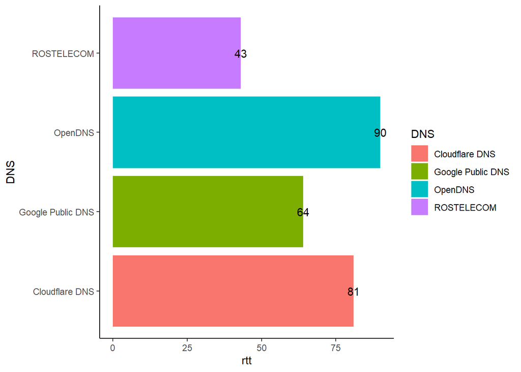

```r
library("ggplot2")
df = read.csv(file = "RTT.csv")
ggplot(data = df, aes(x = DNS, y = rtt, fill = DNS)) + geom_bar(stat = "identity") +
coord_flip() +
geom_text(aes(label = rtt)) + theme_classic()
```

Как мы видим на графике, наименьше RTT(временя передачи сигнала между двумя точками) наблюдается к DHC-серверу моего провайдера, Ростелеком МРФ “ЮГ”. Наибольшее к OpenDNS.

### **Вывод**

Мы познакомились с различными DNS-серверами, научились анализировать сетевые параметры, полученные при работе с командой tracert, которая предназначенна для определения маршрутов следования данных до указаного узла. Научились определять качество соеденения между двумя узлами в сети.